# Data Challenge 38

2026-11-11

```r
library(tidyverse)
```

## Importazione e pulizia dei dati

```r
url <- paste0(
  "https://data.giss.nasa.gov/gistemp/",
  "tabledata_v4/GLB.Ts+dSST.csv"
)

temp_raw <- read_csv(
  url,
  skip = 1,
  na = c("***", "****"),
  show_col_types = FALSE
)

temp <- temp_raw |>
  select(Year, Jan:Dec) |>
  pivot_longer(
    cols = Jan:Dec,
    names_to = "month",
    values_to = "anomaly"
  ) |>
  mutate(
    month = factor(month, levels = month.abb),
    date = as.Date(
      paste(Year, month, "01", sep = "-"),
      format = "%Y-%b-%d"
    )
  ) |>
  drop_na(anomaly)

write_csv(temp, "anomaly.csv")
```

## Esplorazione dataset

Guardiamo la distribuzione dei valori relativi alle anomalie di temperatura per capire come rendere più efficace una rappresentazione artistica del dataset.

```r
anomalies <- read_csv("anomaly.csv")
anomalies
```

```
## # A tibble: 1,761 × 4
##     Year month anomaly date
##    <dbl> <chr>   <dbl> <date>
##  1  1880 Jan     -0.19 1880-01-01
##  2  1880 Feb     -0.25 1880-02-01
##  3  1880 Mar     -0.09 1880-03-01
##  4  1880 Apr     -0.16 1880-04-01
##  5  1880 May     -0.1  1880-05-01
##  6  1880 Jun     -0.21 1880-06-01
##  7  1880 Jul     -0.19 1880-07-01
##  8  1880 Aug     -0.1  1880-08-01
##  9  1880 Sep     -0.15 1880-09-01
## 10  1880 Oct     -0.23 1880-10-01
## # ℹ 1,751 more rows
```

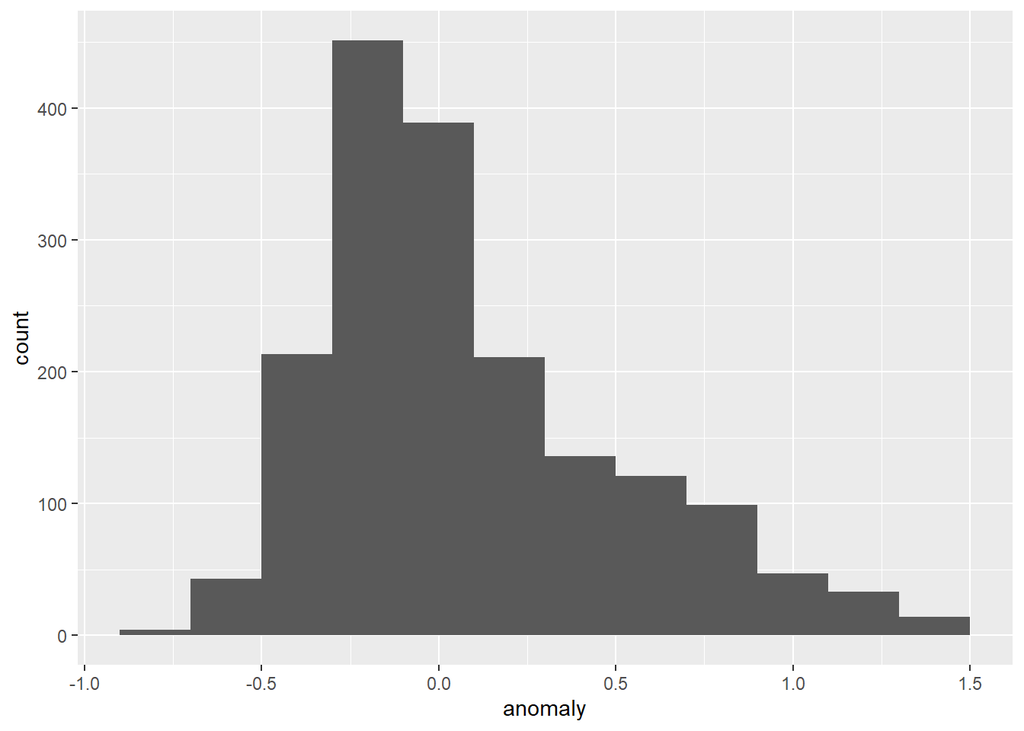

```r
ggplot(data = anomalies, mapping = aes(x = anomaly)) +
  geom_histogram(binwidth = 0.2)
```

```r
anomalies |>
  summarise(minimo = min(anomaly), massimo = max(anomaly), media = mean(anomaly))
```

```
## # A tibble: 1 × 3
##   minimo massimo  media
##    <dbl>   <dbl>  <dbl>
## 1  -0.81    1.48 0.0892
```

```r
anomalies |>
  distinct(Year) |>
  count()
```

```
## # A tibble: 1 × 1
##       n
##   <int>
## 1   147
```

```r
anomalies |>
  summarise(minimo = min(Year), massimo = max(Year))
```

```
## # A tibble: 1 × 2
##   minimo massimo
##    <dbl>   <dbl>
## 1   1880    2026
```

## Creazione della data art

```r
# voglio 144 anni (un numero quadrato)
df1 <- anomalies |>
  filter(1882 <= Year & Year <= 2025) |>
  select(Year, month, anomaly) |>
  mutate(Year = Year - 1882) |>
  rename(anno = Year, mese = month) |>
  mutate(centroX = (anno %% 12) + 1, centroY = 12 - (anno %/% 12))
df1
```

```
## # A tibble: 1,728 × 5
##     anno mese  anomaly centroX centroY
##    <dbl> <chr>   <dbl>   <dbl>   <dbl>
##  1     0 Jan      0.16       1      12
##  2     0 Feb      0.13       1      12
##  3     0 Mar      0.04       1      12
##  4     0 Apr     -0.16       1      12
##  5     0 May     -0.14       1      12
##  6     0 Jun     -0.22       1      12
##  7     0 Jul     -0.16       1      12
##  8     0 Aug     -0.08       1      12
##  9     0 Sep     -0.15       1      12
## 10     0 Oct     -0.23       1      12
## # ℹ 1,718 more rows
```

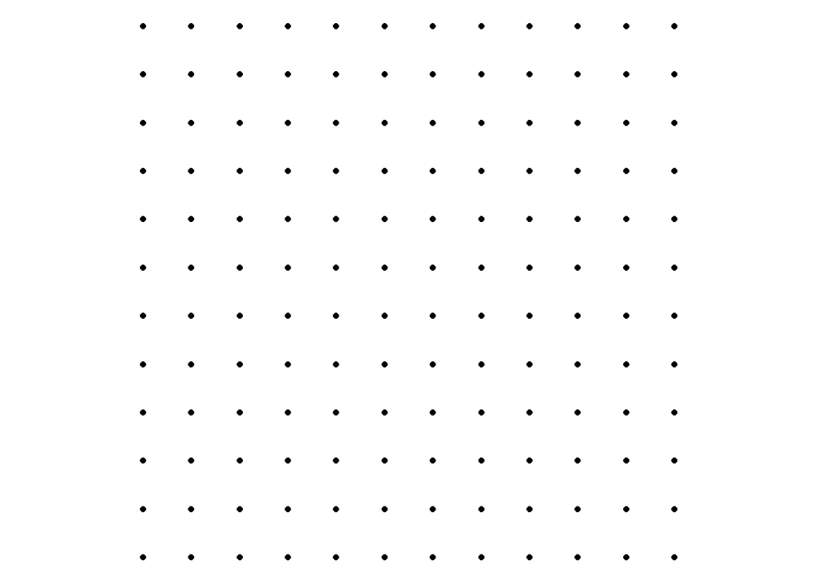

```r
ggplot(data = df1, mapping = aes(x = centroX, y = centroY)) +
  geom_point() +
  coord_fixed() +
  theme_void()
```

Fissiamo dei parametri per l’opera.

```r
a = 0.3
l = 0.5
```

```r
df2 <- df1 |>
  mutate(veroCentroX = centroX + runif(nrow(df1), min = -a, max = a)) |>
  mutate(veroCentroY = centroY + runif(nrow(df1), min = -a, max = a)) |>
  mutate(angolo = runif(nrow(df1), min = 0, max = 2 * pi)) |>
  mutate(inizioX = veroCentroX + l * cos(angolo),
         inizioY = veroCentroY + l * sin(angolo),
         fineX = veroCentroX - l * cos(angolo),
         fineY = veroCentroY - l * sin(angolo))
df2
```

```
## # A tibble: 1,728 × 12
##     anno mese  anomaly centroX centroY veroCentroX veroCentroY angolo inizioX
##    <dbl> <chr>   <dbl>   <dbl>   <dbl>       <dbl>       <dbl>  <dbl>   <dbl>
##  1     0 Jan      0.16       1      12       0.786        12.0   1.51   0.816
##  2     0 Feb      0.13       1      12       0.819        12.0   1.85   0.683
##  3     0 Mar      0.04       1      12       1.29         12.2   1.67   1.24
##  4     0 Apr     -0.16       1      12       1.20         12.0   1.30   1.34
##  5     0 May     -0.14       1      12       1.14         11.8   4.75   1.16
##  6     0 Jun     -0.22       1      12       0.742        12.1   3.42   0.261
##  7     0 Jul     -0.16       1      12       0.732        12.1   2.10   0.479
##  8     0 Aug     -0.08       1      12       1.20         12.1   4.46   1.07
##  9     0 Sep     -0.15       1      12       0.980        11.9   1.33   1.10
## 10     0 Oct     -0.23       1      12       1.27         12.1   5.96   1.74
## # ℹ 1,718 more rows
## # ℹ 3 more variables: inizioY <dbl>, fineX <dbl>, fineY <dbl>
```

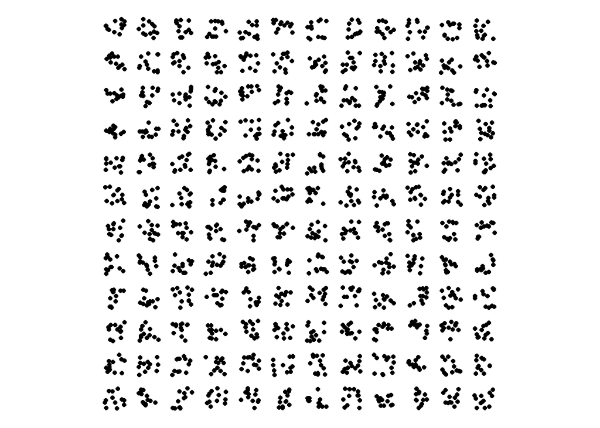

```r
ggplot(data = df2, mapping = aes(x = veroCentroX, y = veroCentroY)) +
  geom_point() +
  coord_fixed() +
  theme_void()
```

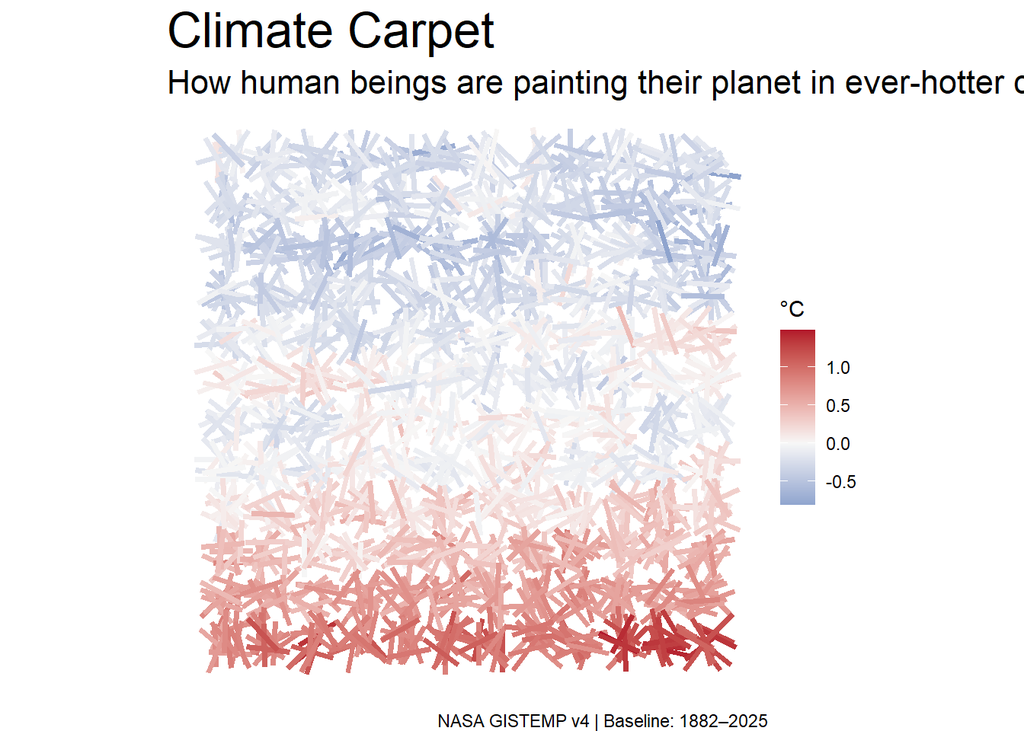

```r
ggplot(data = df2, mapping = aes(x = veroCentroX, y = veroCentroY)) +
  scale_color_gradient2(
    low = "#2166AC",
    mid = "#F7F7F7",
    high = "#B2182B",
    midpoint = 0
  ) +
  #geom_point() +
  geom_segment(mapping = aes(x = inizioX, y = inizioY,
                             xend = fineX, yend = fineY,
                             color = anomaly),
               linewidth = 1.3) +
  labs(
    title = "Climate Carpet",
    subtitle = "How human beings are painting their planet in ever-hotter colours.",
    x = NULL, y = NULL,
    color = "°C",
    caption = "NASA GISTEMP v4 | Baseline: 1882–2025"
  ) +
  coord_fixed() +
  theme_void() +
  theme(
    plot.title = element_text(size = 24),
    plot.subtitle = element_text(size = 16)
  )
```

```r
ggsave("ClimateCarpet.jpg", width = 8, height = 8, dpi = 300)
```

## Spiegazione del mapping della data art

### Origine dell’opera

144 anni di storia climatica sono condensati in un unico quadrato. L’opera è costituita da un quadrato di lato 12, che contiene 144 piccoli quadrati, in ognuno dei quali sono collocati i dati relativi alle anomalie della temperatura in uno specifico anno (si parte dal 1882 in alto a sinistra e si finisce col 2025 in basso a destra). Ogni mese di un anno è rappresentato da un segmento colorato (il colore corrisponde all’anomalia). I segmenti sono disposti a caso nella regione di piano dedicata all’anno cui appartengono.

### Significato

L’opera ricorda un tappeto dalle lunghe frange le cui fibre costitutive sono la storia climatica dell’ultimo secolo e mezzo del pianeta. Sebbene esse siano disposte casualmente a livello locale per ricordare che il fenomeno di cui fanno parte è estremamente complesso e imprevedibile, si nota chiaramente uno spostamento verso i colori più caldi, che diventa quasi oppressivo nella porzione più bassa. La metafora del tappeto rammenta allo spettatore che la responsabilità è dell’umanità che, come un “abile” artigiano, sta modificando il clima, purtroppo a proprio danno.